# cmsc320_project3

```python
import pandas as pd
import numpy as np
data = pd.read_csv("08_gap-every-five-years.tsv", sep='\t')
data.head(20)
```

|  | country | continent | year | lifeExp | pop | gdpPercap |
| --- | --- | --- | --- | --- | --- | --- |
| 0 | Afghanistan | Asia | 1952 | 28.801 | 8425333 | 779.445314 |
| 1 | Afghanistan | Asia | 1957 | 30.332 | 9240934 | 820.853030 |
| 2 | Afghanistan | Asia | 1962 | 31.997 | 10267083 | 853.100710 |
| 3 | Afghanistan | Asia | 1967 | 34.020 | 11537966 | 836.197138 |
| 4 | Afghanistan | Asia | 1972 | 36.088 | 13079460 | 739.981106 |
| 5 | Afghanistan | Asia | 1977 | 38.438 | 14880372 | 786.113360 |
| 6 | Afghanistan | Asia | 1982 | 39.854 | 12881816 | 978.011439 |
| 7 | Afghanistan | Asia | 1987 | 40.822 | 13867957 | 852.395945 |
| 8 | Afghanistan | Asia | 1992 | 41.674 | 16317921 | 649.341395 |
| 9 | Afghanistan | Asia | 1997 | 41.763 | 22227415 | 635.341351 |
| 10 | Afghanistan | Asia | 2002 | 42.129 | 25268405 | 726.734055 |
| 11 | Afghanistan | Asia | 2007 | 43.828 | 31889923 | 974.580338 |
| 12 | Albania | Europe | 1952 | 55.230 | 1282697 | 1601.056136 |
| 13 | Albania | Europe | 1957 | 59.280 | 1476505 | 1942.284244 |
| 14 | Albania | Europe | 1962 | 64.820 | 1728137 | 2312.888958 |
| 15 | Albania | Europe | 1967 | 66.220 | 1984060 | 2760.196931 |
| 16 | Albania | Europe | 1972 | 67.690 | 2263554 | 3313.422188 |
| 17 | Albania | Europe | 1977 | 68.930 | 2509048 | 3533.003910 |
| 18 | Albania | Europe | 1982 | 70.420 | 2780097 | 3630.880722 |
| 19 | Albania | Europe | 1987 | 72.000 | 3075321 | 3738.932735 |

Exercise 1

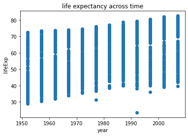

```python
# scatter plot of life expectancy across time
import pandas as pd
import matplotlib.pyplot as plt
plt.scatter(data["year"], data["lifeExp"])
plt.xlabel("year")
plt.ylabel("lifeExp")
plt.title("life expectancy across time")
```

question 1:

Based on the graph shown above, I can conclude that the life expectancy increases as time goes by and the trend is linear. There is a positive relationship between life expectancy and year.

question 2:

I would like to say the distribution of life expectancy across countries for individual years is skewed. All distributions are bimodal. None of these distribution is symmetric around it's center.

question 3:

I will reject the null hypothesis of no relationship.

question 4:

I guess violin plot of residuals from the linear model in q3 would be similar to the violin plot example.

question 5:

The violin plot should be symmetrical and unimodal.

Exercise 2:

```python
from sklearn import linear_model
reg = linear_model.LinearRegression()
year = np.array([[y] for y in data['year']])
exp = np.array([[e] for e in data['lifeExp']])
reg.fit(year, exp)
# The coefficients
print("Coefficients: \t", reg.coef_)
# The intercept
print("Intercept: \t", reg.intercept_)
```

```
Coefficients: 	 [[0.32590383]]
Intercept: 	 [-585.65218744]
```

Question 6:

Based on the data: on average, life expectancy increases 0.3259 every year around the world.

Question 7:

```python
import statsmodels.formula.api as smf
model = smf.ols(formula = "lifeExp ~ year", data = data)
results = model.fit()
print(results.summary())
```

```
                            OLS Regression Results
==============================================================================
Dep. Variable:                lifeExp   R-squared:                       0.190
Model:                            OLS   Adj. R-squared:                  0.189
Method:                 Least Squares   F-statistic:                     398.6
Date:                Mon, 15 Nov 2021   Prob (F-statistic):           7.55e-80
Time:                        20:17:18   Log-Likelihood:                -6597.9
No. Observations:                1704   AIC:                         1.320e+04
Df Residuals:                    1702   BIC:                         1.321e+04
Df Model:                           1
Covariance Type:            nonrobust
==============================================================================
                 coef    std err          t      P>|t|      [0.025      0.975]
------------------------------------------------------------------------------
Intercept   -585.6522     32.314    -18.124      0.000    -649.031    -522.273
year           0.3259      0.016     19.965      0.000       0.294       0.358
==============================================================================
Omnibus:                      386.124   Durbin-Watson:                   0.197
Prob(Omnibus):                  0.000   Jarque-Bera (JB):               90.750
Skew:                          -0.268   Prob(JB):                     1.97e-20
Kurtosis:                       2.004   Cond. No.                     2.27e+05
==============================================================================

Notes:
[1] Standard Errors assume that the covariance matrix of the errors is correctly specified.
[2] The condition number is large, 2.27e+05. This might indicate that there are
strong multicollinearity or other numerical problems.
```

From the statistics shown above, I found that the p-value is 7.55e-80 which is much smaller than 0.05, so I can conclude that there is sufficient evidence to reject the null hypothesis. Therefore, I do reject the null hypothesis and conclude that there actually has relationship between year and life expectancy.

Exercise 3:

```python
!pip install plotnine
!pip install ggplot
```

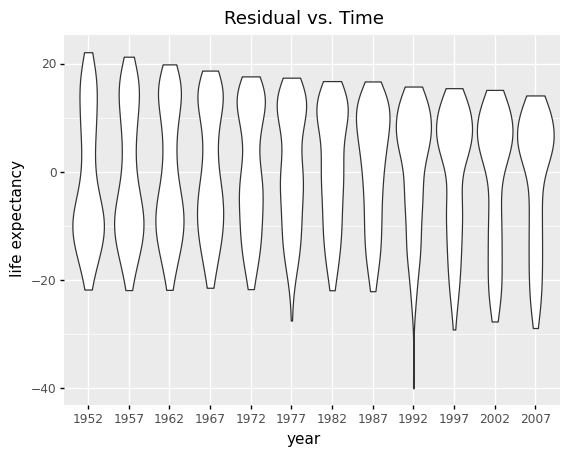

```python
import plotnine as p9
copy = data.copy()
# get the value of coefficient
coef = reg.coef_[0][0]
# get the value of intercept
intercept = reg.intercept_[0]
copy['residual'] = (copy['lifeExp'] - (copy['year']*coef + intercept))
p9.ggplot(copy, p9.aes(x = 'factor(year)', y = 'residual')) + p9.geom_violin() + p9.labs(y = "life expectancy", x = "year", title = 'Residual vs. Time')
```

Exercise 4:

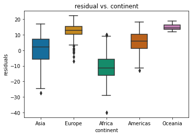

```python
import seaborn as sns
import matplotlib.pyplot as plt

# make a boxplot of model residuals vs. continent
sns.boxplot(y='residual', x='continent', data = copy, width = 0.5, palette = "colorblind")
plt.title("residual vs. continent")
plt.xlabel("continent")
plt.ylabel("residuals")
plt.show()
```

question 9:

There is clear relation between continent and residuals because the residual value is different for each continent. Only using year is not sufficient to predict lifeExp and so we may need to include some other factors.

Exercise 5:

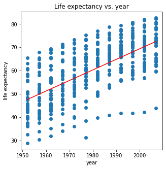

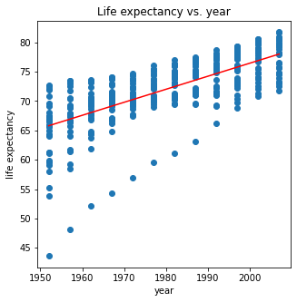

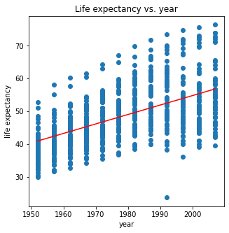

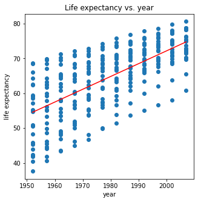

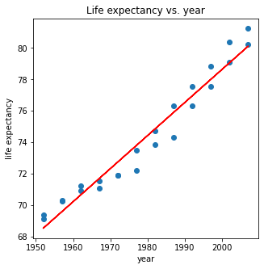

```python
# make a copy of data and group the data by continent and then make a scatter plot per continent
copy1 = data[['continent','year','lifeExp']]
continent_list = data['continent'].unique()
copy1 = copy1.groupby(['continent'])

for c in continent_list:
    exp = copy1.get_group(c)
    x = exp['year']
    y = exp['lifeExp']
    plt.figure(figsize = (5,5))

    # make a scatter plot
    plt.scatter(x,y)
    plt.title("Life expectancy vs. year")
    plt.xlabel('year')
    plt.ylabel('life expectancy')

    # plot regression line: use np.polyfit to find coefficients and then plot it
    coefficients = np.polyfit(x,y,1)
    plt.plot(x, coefficients[0]*x + coefficients[1], c = 'r')
    plt.show()
```

question 10:

Based on the plot, my regression model should include an interaction term for continent and year. Because we can get better prediction on life expectancy with the combinaton of continent and year.

Exercise 6:

```python
#fit a linear regression model for life expectancy including a term for an interaction between continent and year
import statsmodels.formula.api as smf
model = smf.ols(formula = "lifeExp ~ continent*year", data = copy)
results = model.fit()
print(results.summary())
```

```
                            OLS Regression Results
==============================================================================
Dep. Variable:                lifeExp   R-squared:                       0.693
Model:                            OLS   Adj. R-squared:                  0.691
Method:                 Least Squares   F-statistic:                     424.3
Date:                Mon, 15 Nov 2021   Prob (F-statistic):               0.00
Time:                        20:34:38   Log-Likelihood:                -5771.9
No. Observations:                1704   AIC:                         1.156e+04
Df Residuals:                    1694   BIC:                         1.162e+04
Df Model:                           9
Covariance Type:            nonrobust
==============================================================================================
                                 coef    std err          t      P>|t|      [0.025      0.975]
----------------------------------------------------------------------------------------------
Intercept                   -524.2578     32.963    -15.904      0.000    -588.911    -459.605
continent[T.Americas]       -138.8484     57.851     -2.400      0.016    -252.315     -25.382
continent[T.Asia]           -312.6330     52.904     -5.909      0.000    -416.396    -208.870
continent[T.Europe]          156.8469     54.498      2.878      0.004      49.957     263.737
continent[T.Oceania]         182.3499    171.283      1.065      0.287    -153.599     518.298
year                           0.2895      0.017     17.387      0.000       0.257       0.322
continent[T.Americas]:year     0.0781      0.029      2.673      0.008       0.021       0.135
continent[T.Asia]:year         0.1636      0.027      6.121      0.000       0.111       0.216
continent[T.Europe]:year      -0.0676      0.028     -2.455      0.014      -0.122      -0.014
continent[T.Oceania]:year     -0.0793      0.087     -0.916      0.360      -0.249       0.090
==============================================================================
Omnibus:                       27.121   Durbin-Watson:                   0.242
Prob(Omnibus):                  0.000   Jarque-Bera (JB):               44.106
Skew:                          -0.121   Prob(JB):                     2.65e-10
Kurtosis:                       3.750   Cond. No.                     2.09e+06
==============================================================================

Notes:
[1] Standard Errors assume that the covariance matrix of the errors is correctly specified.
[2] The condition number is large, 2.09e+06. This might indicate that there are
strong multicollinearity or other numerical problems.
```

question 11:

Noted that Africa was set as the base to work on. Based on the statistics shown above, since the p-value for Americas, Asia and Europe are smaller than 0.05, we have sufficient evidence to reject the null hypothesis and so conclude that Americas, Asia and Europe in the model are significantly different from zero. Since the p-value for Oceania is larger than 0.05, we are not able to reject the null hypothesis and so conclude that Oceania is not significantly different from zero.

question 12:

Exercise 7:

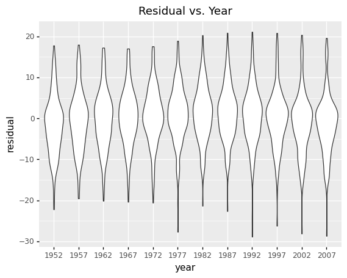

```python
# make a residuals vs. year violin plot for the interaction model
import plotnine as p9
import statsmodels.formula.api as smf
model = smf.ols(formula = "lifeExp ~ continent*year", data = copy).fit()
copy['interaction_residual'] = model.resid
p9.ggplot(copy, p9.aes(x = 'factor(year)', y = 'interaction_residual')) + p9.geom_violin() + p9.labs(x = 'year', y = 'residual', title = 'Residual vs. Year')
```

comment: it does match the assumptions of the linear regression model that the violin plot is symmetrical and unimodal. The mean is approximately equal to 0.

Part 2:

In this part, I am going to use the iris dataset. I will use the informaiton from the feature data to predict if a flower belongs in class Setosa, Versicolour, or Virginica. I am going to use sepal length, sepal width, petal length, and petal width(all measured in cm) as my predictors.

I chose to implement two classification algorithms: KNN classifier and decision tree classifier

1. knn classifier

```python
# choose k-neighbors classifier with n_neighbors = 1
from sklearn import neighbors, datasets
from sklearn.metrics import accuracy_score
iris = datasets.load_iris()
X, y = iris.data, iris.target
knn = neighbors.KNeighborsClassifier(n_neighbors = 1)

# use it to predict labels for data we already know
knn.fit(X, y)
y_model = knn.predict(X)

# compute the fraction of correctly labeled points
accuracy_score(y, y_model)
```

```
1.0
```

Here, I got an accuracy score of 1.0 which means that 100% of points were correctly labeled by the model. However, this approach contains a flaw that is it trains and evaluates the model on the same data. So, I want to use holdout set to redo the analyze.

Now perform holdout validation on knn classifier: holdout sets: hold back some subset of the data from the training of the model, and then use this holdout set to check the model performance

```python
from sklearn.model_selection import train_test_split
# before training the model, split the data into ac
X1, X2, y1, y2 = train_test_split(X, y, random_state = 0, train_size = 0.7)

# fit the model on one set of data
knn.fit(X1, y1)

# evaluate the model on the second set of data
y2_model = knn.predict(X2)

# check accuracy
accuracy_score(y2, y2_model)
```

```
0.9777777777777777
```

From the result shown above, we can see that the nearest-neighbor classifier is about 98% accurate on this holdout set with train_size = 0.7; I trained 70% of the data and create a model based on these data, then holdout 30% of the data to evaluate.

1. decision tree classifier

```python
from sklearn.datasets import load_iris
from sklearn.tree import DecisionTreeClassifier

X, y = iris.data, iris.target
decisionTree = DecisionTreeClassifier(max_depth = 2, random_state = 42)
decisionTree.fit(X, y)
y_model = knn.predict(X)
accuracy_score(y, y_model)
```

```
0.9933333333333333
```

Again perform holdout validation on decision tree classifier:

```python
# split the data into validation train and validation test
Xtrain, Xtest, ytrain, ytest = train_test_split(X, y, random_state = 0, train_size = 0.7)

decisionTree = DecisionTreeClassifier(max_depth = 2, random_state = 42)
# fit the model on one set of data
decisionTree.fit(Xtrain, ytrain)

# evaluate the model on the second set of data
ytest_model = tree_clf.predict(Xtest)

# check accuracy
accuracy_score(ytest, ytest_model)
```

[output not shown]

From the result shown above, we can see that the decision tree classifier is about 91% accurate on this holdout set with train_size = 0.7

Summary: compared the accuracy_score I got from knn classifier with decision tree classifier, I would like to say knn model is doing a better classification job and so has better prediction performance for the iris data.